# DV 3 demo

2022-09-27

```r
library(tidyverse)
library(ggthemes)              # additional ggplot themes
library(ggrepel)               # for additional plot labeling
theme_set(theme_pander())      # set your default theme for this session
```

```r
library(gapminder)
data(gapminder)
```

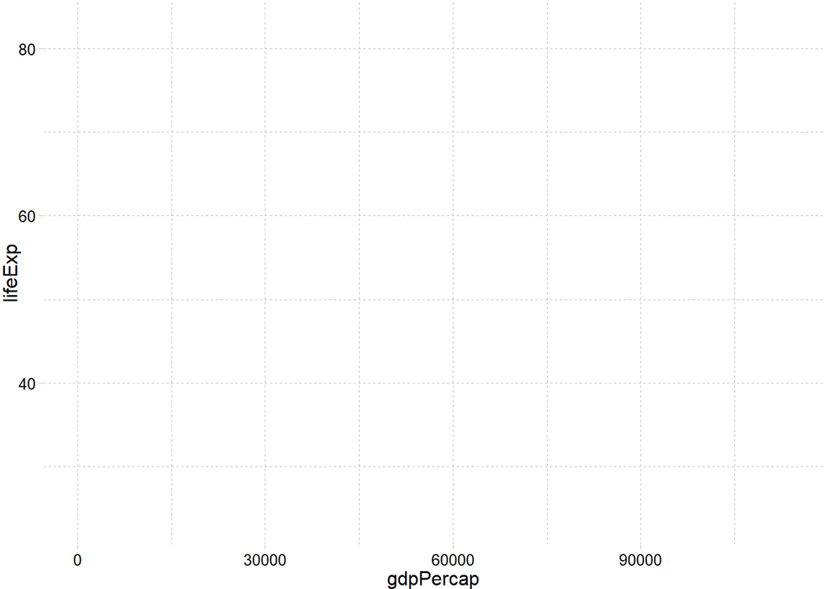

```r
p <- ggplot(gapminder,
            aes(x = gdpPercap,
                y = lifeExp))

p
```

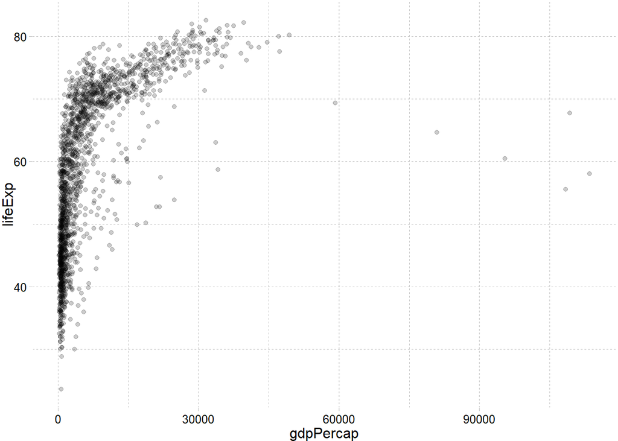

```r
p +
  geom_point(alpha = .2)
```

What is the correlation?

```r
gapminder |>
  select(gdpPercap, lifeExp) |>
  cor()
```

```
##           gdpPercap   lifeExp
## gdpPercap 1.0000000 0.5837062
## lifeExp   0.5837062 1.0000000
```

## What **is** correlation?

Let’s start with a few ideas.

### mean

The mean is the most common measure of the “average” value.

$$\bar{x} = \frac{\sum x_i}{n}$$
Let’s check the mean value of life expectancy in these data.

```r
mean(gapminder$lifeExp)
```

```
## [1] 59.47444
```

### standard deviation

The **standard deviation** is a measure of how spread out the data are.

$$SD_x = \sqrt{\frac{\sum (x_i -
\bar{x})^2}{n-1}}$$
First let’s look at this visually.

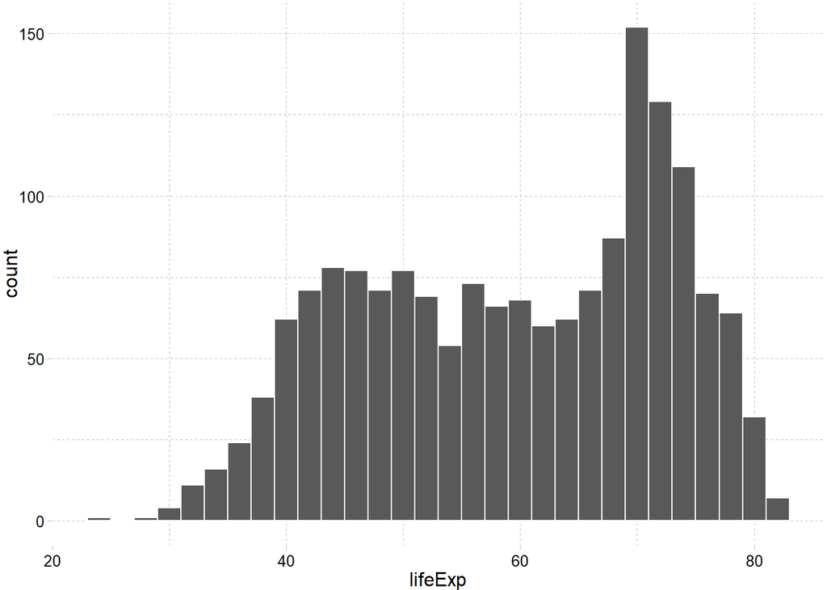

```r
ggplot(gapminder,
       aes(x = lifeExp)) +
  geom_histogram(binwidth = 2,
                 color = "white")
```

ASIDE: if you’re looking to get a good baseline for breaks, try this.

```r
breaks <- pretty(
  gapminder$lifeExp,                   # give it the variable
  nclass.Sturges(gapminder$lifeExp))   # ask "Sturges" to tell you how many bins

breaks
```

```
##  [1] 20 25 30 35 40 45 50 55 60 65 70 75 80 85
```

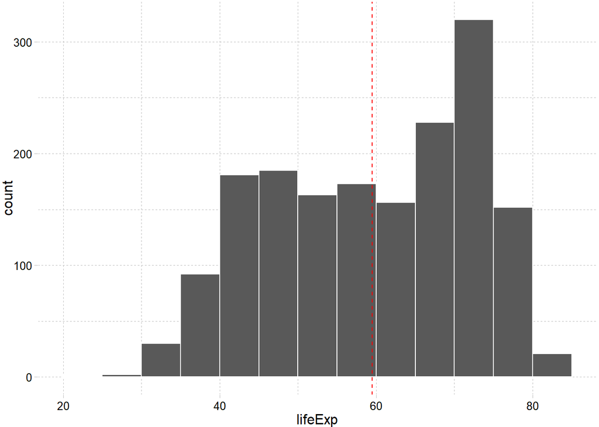

```r
ggplot(gapminder,
       aes(x = lifeExp)) +
  geom_histogram(breaks = breaks,
                 color = "white") +
  geom_vline(xintercept = mean(gapminder$lifeExp),
             color = "red",
             linetype = "dashed")
```

What is the standard deviation here?

```r
sd(gapminder$lifeExp)
```

```
## [1] 12.91711
```

**The “empirical” rule**: if you can’t visualize the data for some reason, it’s a reasonable approximation to estimate that 68% of the data lie within 1 SD of the mean and 95% lie within 2 SDs of the mean.

### standardized variable

Variables are measured in units like dollars or years. If we want a “unitless” measure of something, we can *standardize* a variable. Let’s call that variable $x^*$.

$$x^*_i =
\frac{x_i-\bar{x}}{SD_x}$$
The unit now is “how many standard deviations from the mean is this observation”?

### correlation

To calculate the correlation between two variables, we need both variables standardized. Then apply this formula:

$$r_{xy} = \frac{\sum x^*_i y^*_i}{n}$$
The idea here is when one variable is 1 standard deviation higher, the other variable will be $r_{xy}$ standard deviations higher.

```r
library(toRvik)
d <- bart_player_game(stat = "shooting")
```

```r
dd <- d |>
  select(player, team, two_m, two_a, three_m, three_a) |>
  group_by(player, team) |>
  summarize(across(two_m:three_a,
                   ~ sum(.x)),
            .groups = "drop") |>
  filter(three_a > 50 & two_m > 50) |>
  mutate(three_pct = (three_m/three_a)*100,
         two_pct = (two_m/two_a)*100)
```

```r
dd |>
  select(three_pct,two_pct) |>
  cor()
```

```
##            three_pct    two_pct
## three_pct 1.00000000 0.04724163
## two_pct   0.04724163 1.00000000
```